# Trasporto per conduzione

## Calcolo della portata di calore in una parete

Per poter calcolare la portata di calore alla parete, occorre conoscere le dimensioni della parete, il materiale di cui questa è composta e la temperatura lato interno e lato esterno.

### Costanti

Il materiale considerato per la parete è argilla regrattaria.

```matlab
% Conducibilità termica [W/(m*K)]
k = 1.7;
```

### Variabili

Dimensioni caratteristiche del sistema specifico in esame.

```matlab
%Dimensioni del sistema
H = 0.5;            %Altezza [m]
W = 1.2;            %Larghezza [m]
L = 0.30;           %Spessore [m]

%Temperature
T1 = 900;          %Parete - Lato 1 [K]
T2 = 1000;          %Parete - Lato 2 [K]
```

Per il calcolo del flusso termico viene utilizzata la legge di Fourier. $$q_x = -k\frac{dT}{dx} = k \frac{T_1-T_2}{L}$$

```matlab
%Calcolo della portata termica
q = k*(T1-T2)/L;   %Portata termica [W/m^2]

%Stampa risultato
fprintf('Il valore della portata termica attraverso la parete è: %4.1f W/m^2',q)
```

```
Il valore della portata termica attraverso la parete è: -566.7 W/m^2
```

## Distribuzione di temperatura nella sezione di una parete

```matlab
%Dimensioni del sistema
H = 0.5;            %Altezza [m]
W = 1.2;            %Larghezza [m]
L = 0.30;           %Spessore [m]

%Temperature
T1 = 900;           %Parete - Lato 1 [K]

%Flusso termico [W/m^2]
q = 1000;

%Vettore condizioni iniziali
T = T1;

%Vettore lunghezze
x=linspace(0,L,100);

%Risolutore ODEs
options = odeset('RelTol',1e-6);
[xsol,Tsol] = ode15s(@TBs,x,T,options,k,q);
```

```matlab
function [sol] = TBs(x,T,k,q)
dtdx = -q*k
end
```

## Grafici

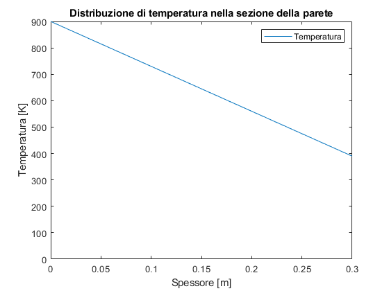

```matlab
plot(xsol,Tsol)
xlabel('Spessore [m]')
ylabel('Temperatura [K]')
title('Distribuzione di temperatura nella sezione della parete')
legend('Temperatura')
axis([0 max(xsol) 0 max(Tsol)])
```

### Osservazioni

Considerando il valore del flusso di calore costante lungo la sessione si ottiene un profilo lineare.

## Profilo attraverso materiali con diversa conducibilità termica

Considerando le dimensioni della parete definite in precedenza si ipotizza di valutare la variazione di T al variare della composizione.  
Nell'esempio di seguito si considerano lastre di Teflon, Granito e Quarzite.  
Per la valutazione del valore della conducibilità termica questa viene considerata costante lungo la sezione, questa ipotesi può essere applicata perchè la variazione di temperatura non sia troppo elevata, in particolare i valori numerici vengono ricavati dall'Incropera, alla temperatura di 300 K.

### Costanti del sistema

```matlab
k1 = 0.35;                  %Teflon [W/(m*K)];
k2 = 2.79;                  %Granito [W/(m*K)];
k3 = 5.38;                  %Quarzite [W/(m*K)];

%Vettore delle conducibilità termiche
K = [k1 k2 k3];

%Dimensioni del sistema
H = 0.5;            %Altezza [m]
W = 1.2;            %Larghezza [m]
L = 0.05;           %Spessore [m]

%Temperature
T1 = 350;           %Parete - Lato 1 [K]

%Flusso termico [W/m^2]
q = 1000;

%Vettore condizioni iniziali
T = T1;

x=linspace(0,L,100);       %Vettore lunghezze [m]
```

```matlab
for i=1:1:length(K)
%Risolutore ODEs
options = odeset('RelTol',1e-6);
[xsol(:,i),Tsol(:,i)] = ode15s(@TBs,x,T,options,K(i),q);
end
```

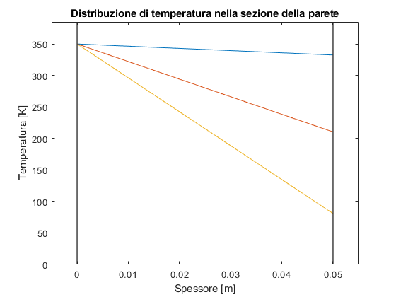

```matlab
legT=[];
for i=1:1:length(K)
plot(xsol(:,i),Tsol(:,i)), hold on
xlabel('Spessore [m]')
ylabel('Temperatura [K]')
title('Distribuzione di temperatura nella sezione della parete')
X(i) = max(xsol(:,i));
T(i) = max(Tsol(:,i));
drawnow
end
maxX = max(X)*1.1;
maxT = max(T)*1.1;
axis([-L*0.1 maxX 0 maxT]);
xline(0,'HandleVisibility','off','linewidth',2);
xline(L,'HandleVisibility','off','linewidth',2);
```

## Distribuzione della temperatura attraverso la parete a flusso variabile

Il flusso di calore all'interno della parete viene definito linearmente come: $$q = axT + b$$ Considerando il flusso nel lato 1 della parete come 1000 alla temperatura di 350 K si ottiene un valore di b = 1000.
Utilizzando la temperatura stimata per lo stato stazionario come iniziale per il calcolo del valore di a si ottiene, per flusso nullo un valore di:

```matlab
L = 0.1;
b = 1000;
Ta = 332;          %Temperatura [K]

%Stima iniziale di a
a = -b/(L*Ta);
```

### Grafico del valore di q nella sezione

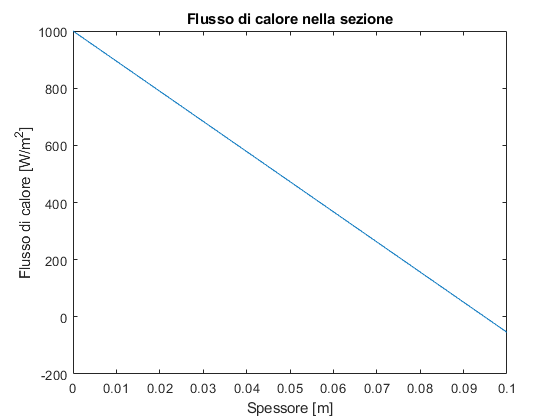

```matlab
x = linspace(0,L,100);
q = a.*x*T1 + b;
plot(x,q)
xlabel('Spessore [m]')
ylabel('Flusso di calore [W/m^2]')
title('Flusso di calore nella sezione')
```

```matlab
k1= 0.35;                  %Teflon [W/(m*K)];

%Temperature
T1 = 350;           %Parete - Lato 1 [K]

%Flusso termico [W/m^2]
q = 1000;

%Vettore condizioni iniziali
T = T1;

x=linspace(0,L,100);       %Vettore lunghezze [m]

options = odeset('RelTol',1e-6);
[xsolq,Tsolq] = ode15s(@TBsq,x,T,options,k1,a,b);
```

```matlab
function [dtdx] = TBsq(x,T,k,a,b)
q = a*x*T + b;
dtdx = -q*k;
end
```

```
Controllare che il valore alla lunghezza L sia lo stesso imposto per il calcolo preliminare del valore a,(Ta) in caso contrario modificarlo!!!
```

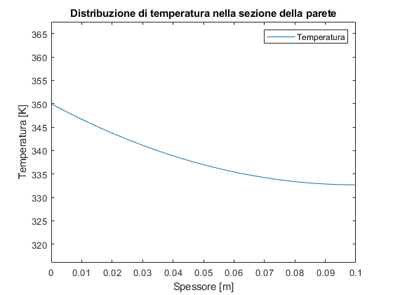

```matlab
plot(xsolq,Tsolq)
xlabel('Spessore [m]')
ylabel('Temperatura [K]')
title('Distribuzione di temperatura nella sezione della parete')
legend('Temperatura')
axis([0 max(xsolq) min(Tsolq)*0.95 max(Tsolq)*1.05])
Differenza = Ta - Tsolq(length(Tsolq));
fprintf('Controllare che il valore alla lunghezza L sia lo stesso imposto per il calcolo preliminare del valore a,(Ta) in caso contrario modificarlo!!!')
```

Utilizzando il metodo partendo dallo stato stazionario, si ottiene una relazione che modificando $T_a$ può essere modificata per ottenere il valore finale del sistema.  
Si può notare come il profilo di temperatura all'interno della parete in questa configurazione sia di grado superiore al primo.